# 財務實證資料分析-作業4

7110021065 吳憲中

2021/10/27

```r
library("png")
library("Rcpp")
library("RcppZiggurat")
library("dplyr")
library("tseries")
library("forecast")
library("randtests")
```

```r
library("ggplot2")
library("Rfast")
library("EnvStats")
TW <- read.csv("C:/Users/stran/OneDrive/桌面/碩士班/碩一上/財務實證資料分析/作業4/TW2020.csv", header=T)
TF <- read.csv("C:/Users/stran/OneDrive/桌面/碩士班/碩一上/財務實證資料分析/作業4/TF2020.csv", header=T)
TW_open <- TW$X09.00.00
TW_close <- TW$X13.30.00
TW_return_daily <- diff(log(TW_close)) * 100
TW_return_interday <- (log(TW_close) - log(TW_open))*100
TW_cumulative_return_intraday<-(log(TW)-log(TW_open))*100
TW_cumulative_return_intraday <- colMeans(TW_cumulative_return_intraday)
TF<-na.omit(TF)
TF_open <- TF$X08.46.00
TF_close <- TF$X13.45.00
TF_return_daily <- diff(log(TF_close)) * 100
TF_return_interday <- (log(TF_close) - log(TF_open))*100
TF_cumulative_return_intraday<-(log(TF)-log(TF_open))*100
TF_cumulative_return_intraday <- colMeans(TF_cumulative_return_intraday)
```

##### About $\lbrace{Cr_{i,t}^W,i=1,2,\ldots,n}\rbrace$ and $\lbrace{Cr_{i,t}^F,i=1,2,\ldots,n}\rbrace$,

##### We use the means of each columns to represent all elements in specific “t” to make there’s only one element in each column and there’s only one row.So we make this set to represent the **“specific $i$th day** .

# **Question1.**

#### For the following test,we assume $\alpha=0.05$

### **1-(a)**

#### Draw the time series plot for the samples $\lbrace{P_{i,Tw}^W,i=1,2,\ldots,n}\rbrace$ and $\lbrace{P_{i,Tf}^F,i=1,2,\ldots,n}\rbrace$.

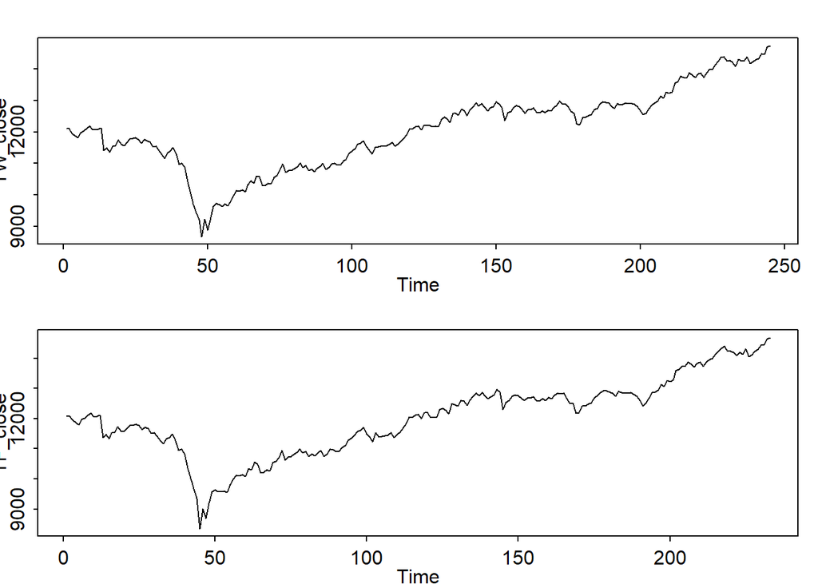

```r
graphics.off()
win.graph()
par(mfrow=c(2,1),mex=0.4)
ts.plot(TW_close)
ts.plot(TF_close)
```

### **1-(b)**

#### Are the samples $\lbrace{P_{i,Tw}^W,i=1,2,\ldots,n}\rbrace$ and $\lbrace{P_{i,Tf}^F,i=1,2,\ldots,n}\rbrace$ random $?$

```r
runs.test(TW_close)
```

```
##
##  Runs Test
##
## data:  TW_close
## statistic = -14.755, runs = 8, n1 = 122, n2 = 122, n = 244, p-value <
## 2.2e-16
## alternative hypothesis: nonrandomness
```

```r
runs.test(TF_close)
```

```
##
##  Runs Test
##
## data:  TF_close
## statistic = -14.343, runs = 8, n1 = 116, n2 = 116, n = 232, p-value <
## 2.2e-16
## alternative hypothesis: nonrandomness
```

##### By the Run-tests,we know that $p-values$ of $\lbrace{P_{i,Tw}^W,i=1,2,\ldots,n}\rbrace$ and $\lbrace{P_{i,Tf}^F,i=1,2,\ldots,n}\rbrace$ are **smaller** than $0.025$,

##### so they’re **not random**.

### **1-(c)**

#### Are the samples $\lbrace{P_{i,Tw}^W,i=1,2,\ldots,n}\rbrace$ and $\lbrace{P_{i,Tf}^F,i=1,2,\ldots,n}\rbrace$ from Gaussian distributions $?$

```r
jarque.bera.test(TW_close)
```

```
##
##  Jarque Bera Test
##
## data:  TW_close
## X-squared = 2.1078, df = 2, p-value = 0.3486
```

```r
jarque.bera.test(TF_close)
```

```
##
##  Jarque Bera Test
##
## data:  TF_close
## X-squared = 1.7759, df = 2, p-value = 0.4115
```

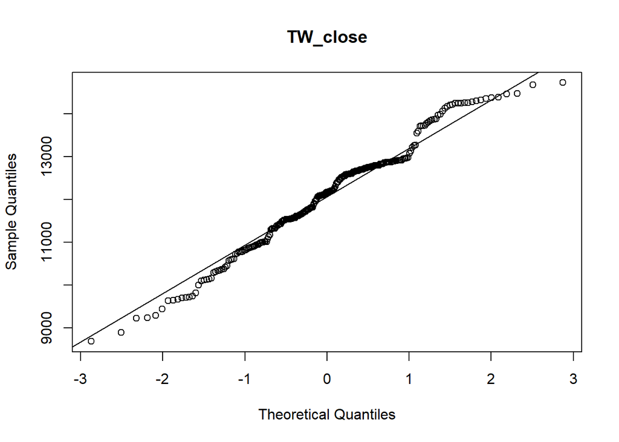

```r
qqnorm(TW_close,main = "TW_close")
qqline(TW_close)
```

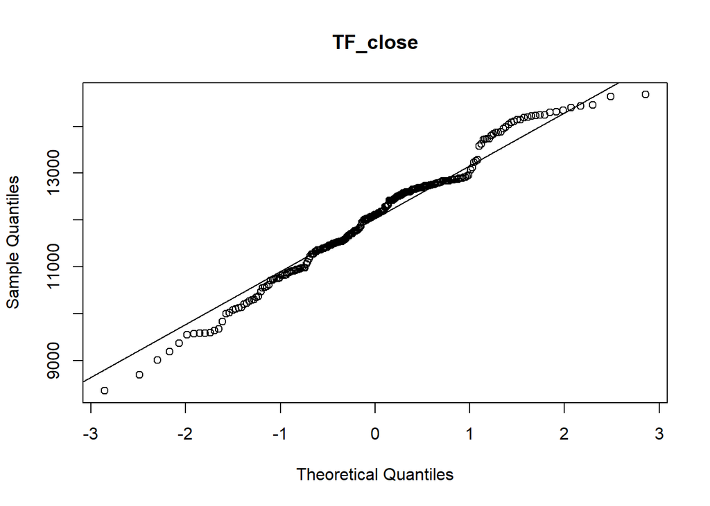

```r
qqnorm(TF_close,main = "TF_close")
qqline(TF_close)
```

##### By the QQ-plot,it seems that $\lbrace{P_{i,Tw}^W,i=1,2,\ldots,n}\rbrace$ and $\lbrace{P_{i,Tf}^F,i=1,2,\ldots,n}\rbrace$

##### are **not** form **Gaussian distribution**.

##### But by *Jarque Bera Test* their $p-value$ are **greater** than $0.025$,

##### which means $\lbrace{P_{i,Tw}^W,i=1,2,\ldots,n}\rbrace$ and $\lbrace{P_{i,Tf}^F,i=1,2,\ldots,n}\rbrace$

##### are from **Gaussian distribution**.

### **1-(d)**

#### Are the samples $\lbrace{P_{i,Tw}^W,i=1,2,\ldots,n}\rbrace$ and $\lbrace{P_{i,Tf}^F,i=1,2,\ldots,n}\rbrace$ stationary $?$

```r
kpss.test(TW_close, null = "Trend")
```

```
##
##  KPSS Test for Trend Stationarity
##
## data:  TW_close
## KPSS Trend = 0.43785, Truncation lag parameter = 5, p-value = 0.01
```

```r
kpss.test(TF_close, null = "Trend")
```

```
##
##  KPSS Test for Trend Stationarity
##
## data:  TF_close
## KPSS Trend = 0.49579, Truncation lag parameter = 4, p-value = 0.01
```

##### By *kpss.test* we can see that both $p-value$ of sample are **smaller** than $critical\ value$,

##### so we have significance level to say the sample are **not stationary**.

### **1-(e)**

#### Draw the time series plot for the samples $\lbrace{r_i^W,i=1,2,\ldots,n}\rbrace$ and $\lbrace{r_i^F,i=1,2,\ldots,n}\rbrace$.

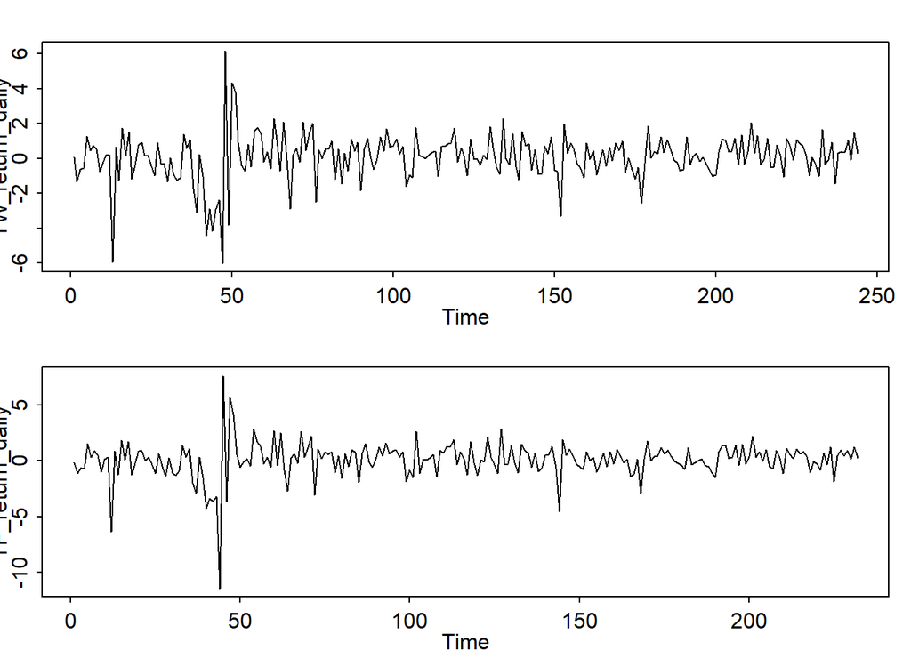

```r
graphics.off()
win.graph()
par(mfrow=c(2,1),mex=0.4)
ts.plot(TW_return_daily)
ts.plot(TF_return_daily)
```

### **1-(f)**

#### Are the samples $\lbrace{r_i^W,i=1,2,\ldots,n}\rbrace$ and $\lbrace{r_i^F,i=1,2,\ldots,n}\rbrace$ random $?$

```r
runs.test(TW_return_daily )
```

```
##
##  Runs Test
##
## data:  TW_return_daily
## statistic = -0.89811, runs = 116, n1 = 122, n2 = 122, n = 244, p-value
## = 0.3691
## alternative hypothesis: nonrandomness
```

```r
runs.test(TF_return_daily )
```

```
##
##  Runs Test
##
## data:  TF_return_daily
## statistic = -0.13159, runs = 116, n1 = 116, n2 = 116, n = 232, p-value
## = 0.8953
## alternative hypothesis: nonrandomness
```

### **1-(g)**

#### Are the samples $\lbrace{r_i^W,i=1,2,\ldots,n}\rbrace$ and $\lbrace{r_i^F,i=1,2,\ldots,n}\rbrace$ from Gaussian distributions $?$

```r
jarque.bera.test(TW_return_daily)
```

```
##
##  Jarque Bera Test
##
## data:  TW_return_daily
## X-squared = 288.59, df = 2, p-value < 2.2e-16
```

```r
jarque.bera.test(TF_return_daily)
```

```
##
##  Jarque Bera Test
##
## data:  TF_return_daily
## X-squared = 1707.9, df = 2, p-value < 2.2e-16
```

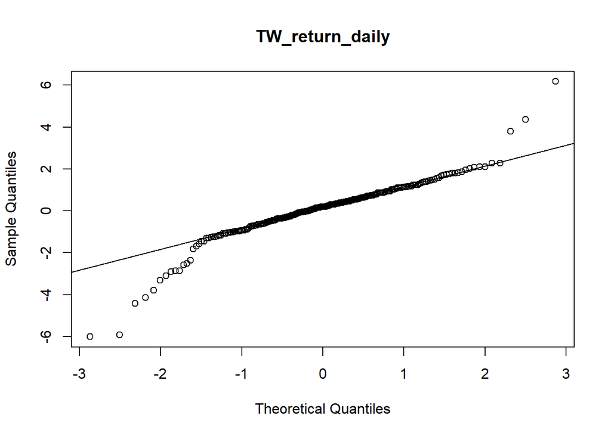

```r
qqnorm(TW_return_daily,main = "TW_return_daily")
qqline(TW_return_daily)
```

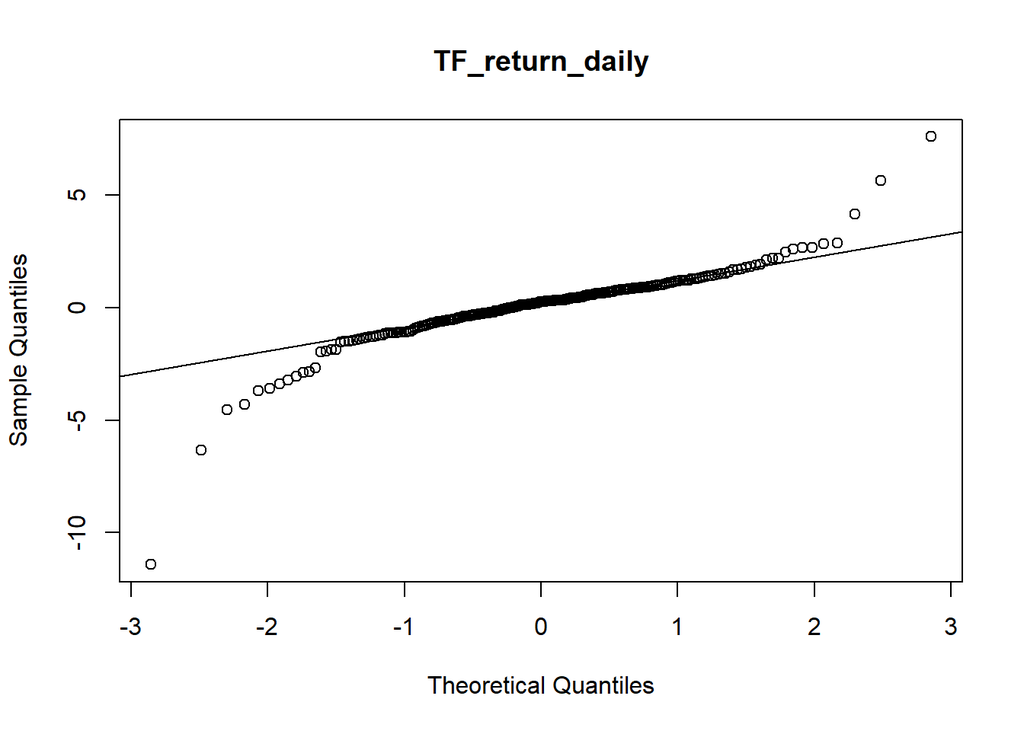

```r
qqnorm(TF_return_daily,main = "TF_return_daily")
qqline(TF_return_daily)
```

##### By the QQ-plot,it seems that $\lbrace{r_i^W,i=1,2,\ldots,n}\rbrace$ and $\lbrace{r_i^F,i=1,2,\ldots,n}\rbrace$

##### are **not** form **Gaussian distribution**.

##### And by *Jarque Bera Test* their $p-value$ are **smaller** than $0.025$,

##### which means $\lbrace{r_i^W,i=1,2,\ldots,n}\rbrace$ and $\lbrace{r_i^F,i=1,2,\ldots,n}\rbrace$

##### are **not** from **Gaussian distribution**.

### **1-(h)**

#### Are the samples $\lbrace{r_i^W,i=1,2,\ldots,n}\rbrace$ and $\lbrace{r_i^F,i=1,2,\ldots,n}\rbrace$} stationary $?$

```r
kpss.test(TW_return_daily, null = "Trend")
```

```
##
##  KPSS Test for Trend Stationarity
##
## data:  TW_return_daily
## KPSS Trend = 0.076324, Truncation lag parameter = 4, p-value = 0.1
```

```r
kpss.test(TF_return_daily, null = "Trend")
```

```
##
##  KPSS Test for Trend Stationarity
##
## data:  TF_return_daily
## KPSS Trend = 0.066614, Truncation lag parameter = 4, p-value = 0.1
```

##### By *kpss.test* we can see that both $p-value$ of sample are **greater** than $critical\ value$,

##### so we have significance level to say the sample are **stationary**.

### **1-(i)**

#### Draw the time series plot for the samples $\lbrace{Ir_i^W,i=1,2,\ldots,n}\rbrace$ and $\lbrace{Ir_i^F,i=1,2,\ldots,n}\rbrace$.

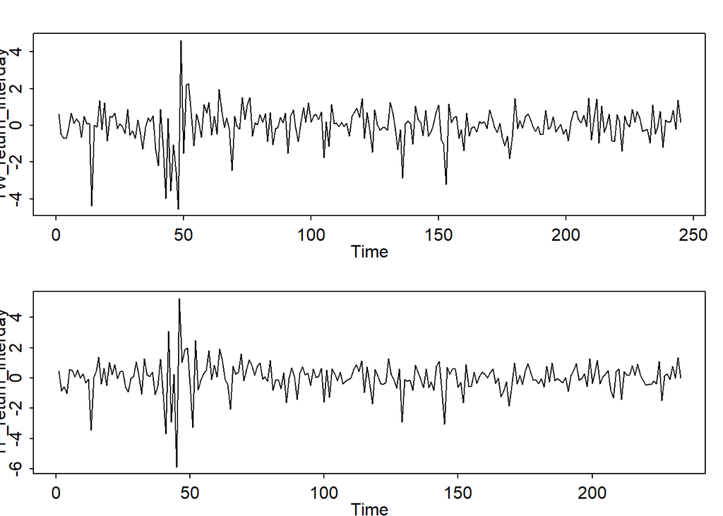

```r
graphics.off()
win.graph()
par(mfrow=c(2,1),mex=0.4)
ts.plot(TW_return_interday)
ts.plot(TF_return_interday)
```

### **1-(j)**

#### Are the samples $\lbrace{Ir_i^W,i=1,2,\ldots,n}\rbrace$ and $\lbrace{Ir_i^F,i=1,2,\ldots,n}\rbrace$ random $?$

```r
runs.test(TW_return_interday )
```

```
##
##  Runs Test
##
## data:  TW_return_interday
## statistic = -0.2566, runs = 121, n1 = 122, n2 = 122, n = 244, p-value =
## 0.7975
## alternative hypothesis: nonrandomness
```

```r
runs.test(TF_return_interday )
```

```
##
##  Runs Test
##
## data:  TF_return_interday
## statistic = -0.39477, runs = 114, n1 = 116, n2 = 116, n = 232, p-value
## = 0.693
## alternative hypothesis: nonrandomness
```

### **1-(k)**

#### Are the samples $\lbrace{Ir_i^W,i=1,2,\ldots,n}\rbrace$ and $\lbrace{Ir_i^F,i=1,2,\ldots,n}\rbrace$ from Gaussian distributions $?$

```r
jarque.bera.test(TW_return_interday)
```

```
##
##  Jarque Bera Test
##
## data:  TW_return_interday
## X-squared = 332.44, df = 2, p-value < 2.2e-16
```

```r
jarque.bera.test(TF_return_interday)
```

```
##
##  Jarque Bera Test
##
## data:  TF_return_interday
## X-squared = 553.96, df = 2, p-value < 2.2e-16
```

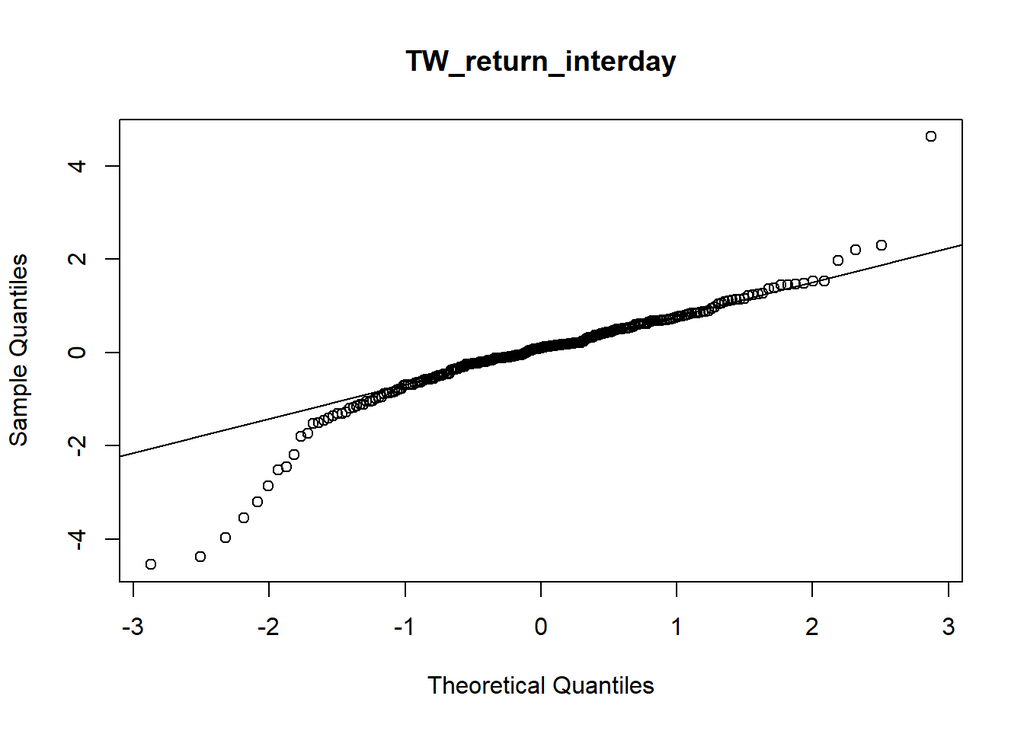

```r
qqnorm(TW_return_interday,main = "TW_return_interday")
qqline(TW_return_interday)
```

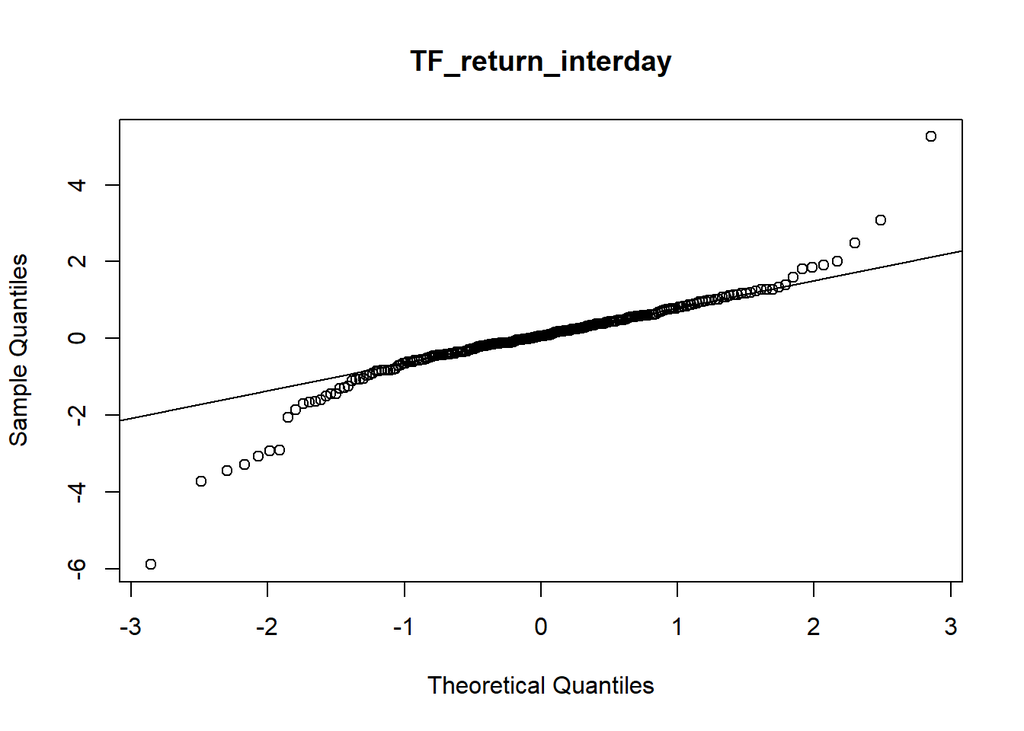

```r
qqnorm(TF_return_interday,main = "TF_return_interday")
qqline(TF_return_interday)
```

##### By the QQ-plot,it seems that $\lbrace{Ir_i^W,i=1,2,\ldots,n}\rbrace$ and $\lbrace{Ir_i^F,i=1,2,\ldots,n}\rbrace$

##### are **not** form **Gaussian distribution**.

##### And by *Jarque Bera Test* their $p-value$ are **smaller** than $0.025$,

##### which means $\lbrace{Ir_i^W,i=1,2,\ldots,n}\rbrace$ and $\lbrace{Ir_i^F,i=1,2,\ldots,n}\rbrace$

##### are **not** from **Gaussian distribution**.

### **1-(l)**

#### Are the samples $\lbrace{Ir_i^W,i=1,2,\ldots,n}\rbrace$ and $\lbrace{Ir_i^F,i=1,2,\ldots,n}\rbrace$ stationary $?$

```r
kpss.test(TW_return_daily, null = "Trend")
```

[output not shown]

```r
kpss.test(TF_return_daily, null = "Trend")
```

[output not shown]

##### so we have significance level to say the sample are **stationary**.

### **1-(m)**

#### Draw the time series plot for the samples $\lbrace{Cr_{i,t}^W,i=1,2,\ldots,n}\rbrace$ and $\lbrace{Cr_{i,t}^F,i=1,2,\ldots,n}\rbrace$ for a

#### specific $i$.

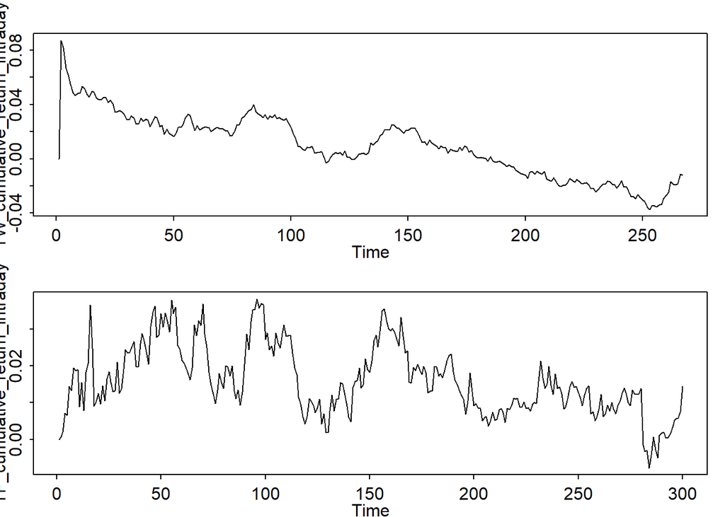

```r
graphics.off()
win.graph()
par(mfrow=c(2,1),mex=0.4)
ts.plot(TW_cumulative_return_intraday)
ts.plot(TF_cumulative_return_intraday)
```

### **1-(n)**

#### Are the samples $\lbrace{Cr_{i,t}^W,i=1,2,\ldots,n}\rbrace$ and $\lbrace{Cr_{i,t}^F,i=1,2,\ldots,n}\rbrace$ for a specific $i$ random $?$

```r
runs.test(TW_cumulative_return_intraday )
```

```
##
##  Runs Test
##
## data:  TW_cumulative_return_intraday
## statistic = -15.357, runs = 9, n1 = 133, n2 = 133, n = 266, p-value <
## 2.2e-16
## alternative hypothesis: nonrandomness
```

```r
runs.test(TF_cumulative_return_intraday )
```

```
##
##  Runs Test
##
## data:  TF_cumulative_return_intraday
## statistic = -12.145, runs = 46, n1 = 150, n2 = 150, n = 300, p-value <
## 2.2e-16
## alternative hypothesis: nonrandomness
```

##### By the *Run-tests*,we know that $pvalues$ of $\lbrace{Cr_{i,t}^W,i=1,2,\ldots,n}\rbrace$ and $\lbrace{Cr_{i,t}^F,i=1,2,\ldots,n}\rbrace$ are **smaller** than $0.025$,

##### so they’re **not random**.

### **1-(o)**

#### Are the samples $\lbrace{Cr_{i,t}^W,i=1,2,\ldots,n}\rbrace$ and $\lbrace{Cr_{i,t}^F,i=1,2,\ldots,n}\rbrace$ for a specific $i$ from Gaussian.

#### distributions?

```r
jarque.bera.test(TW_cumulative_return_intraday)
```

```
##
##  Jarque Bera Test
##
## data:  TW_cumulative_return_intraday
## X-squared = 1.5996, df = 2, p-value = 0.4494
```

```r
jarque.bera.test(TF_cumulative_return_intraday)
```

```
##
##  Jarque Bera Test
##
## data:  TF_cumulative_return_intraday
## X-squared = 8.2028, df = 2, p-value = 0.01655
```

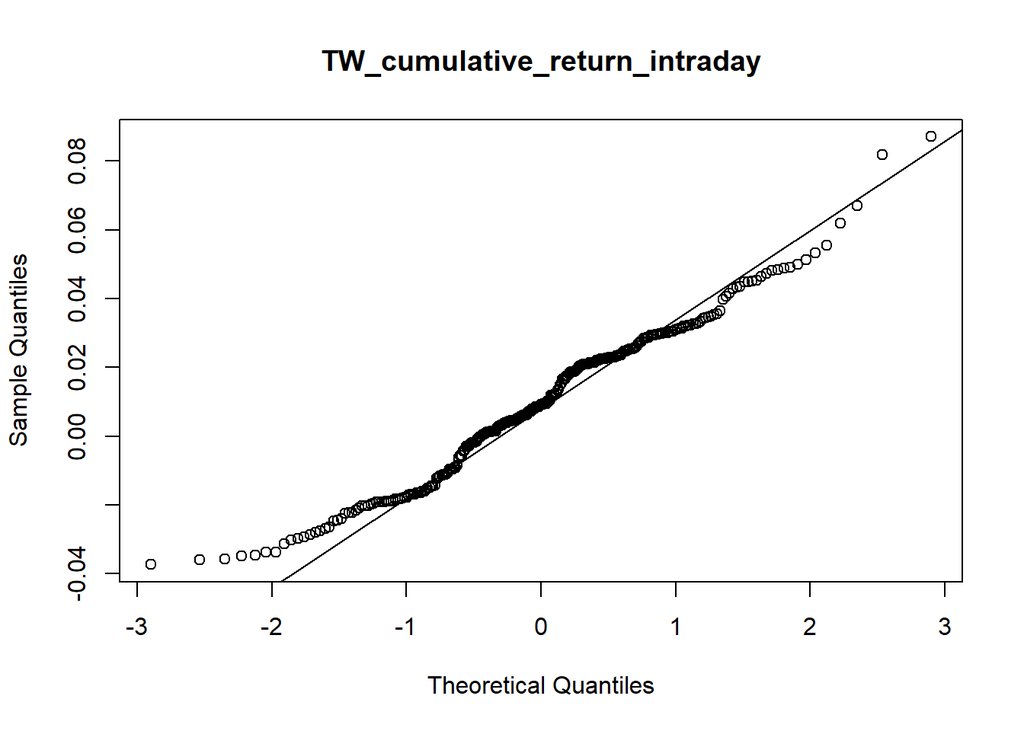

```r
qqnorm(TW_cumulative_return_intraday,main = "TW_cumulative_return_intraday")
qqline(TW_cumulative_return_intraday)
```

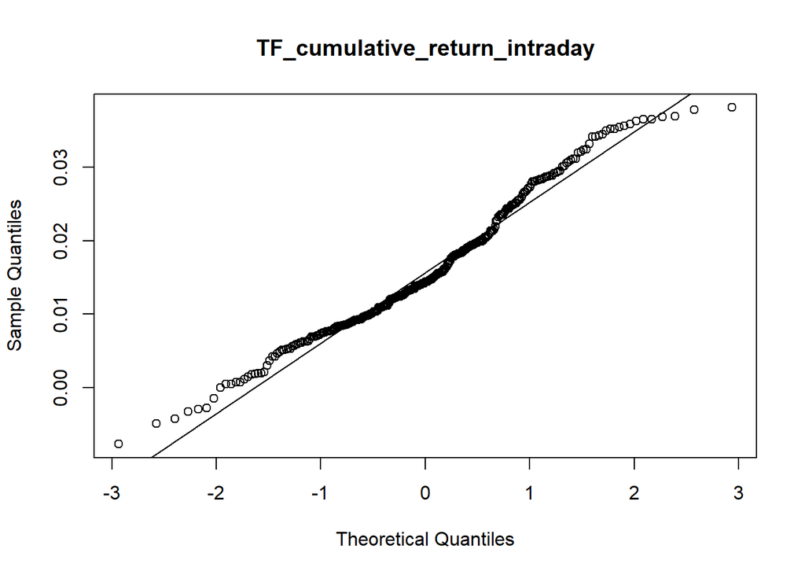

```r
qqnorm(TF_cumulative_return_intraday,main = "TF_cumulative_return_intraday")
qqline(TF_cumulative_return_intraday)
```

##### By the QQ-plot,it seems that $\lbrace{Cr_{i,t}^W,i=1,2,\ldots,n}\rbrace$ and $\lbrace{Cr_{i,t}^F,i=1,2,\ldots,n}\rbrace$

##### are **not** form **Gaussian distribution**.

##### But by *Jarque Bera Test* ,

##### $p-value$ of $Cr_{i,t}^W$ is **greater** than $0.025$, which means $\lbrace{Cr_{i,t}^W,i=1,2,\ldots,n}\rbrace$ is from **Gaussian distribution**,

##### and $p-value$ of $Cr_{i,t}^F$ is **smaller** than $0.025$, which means $\lbrace{Cr_{i,t}^F,i=1,2,\ldots,n}\rbrace$ is **not** from **Gaussian distribution**.

### **1-(p)**

#### Are the samples $\lbrace{Cr_{i,t}^W,i=1,2,\ldots,n}\rbrace$ and $\lbrace{Cr_{i,t}^F,i=1,2,\ldots,n}\rbrace$ for a specific $i$ stationary $?$

```r
kpss.test(TW_cumulative_return_intraday, null = "Trend")
```

```
##
##  KPSS Test for Trend Stationarity
##
## data:  TW_cumulative_return_intraday
## KPSS Trend = 0.18713, Truncation lag parameter = 5, p-value = 0.02083
```

```r
kpss.test(TF_cumulative_return_intraday, null = "Trend")
```

```
##
##  KPSS Test for Trend Stationarity
##
## data:  TF_cumulative_return_intraday
## KPSS Trend = 0.21198, Truncation lag parameter = 5, p-value = 0.01151
```

##### By *kpss.test* we can see that both $p-value$ of sample are **smaller** than $critical\ value$,

##### so we have significance level to say the sample are **not stationary**.

# **Question2.**

#### We assume $\alpha = 0.05$

### **2-(a)**

#### Is the mean of close price of TAIEX equal to $10000 ?$

```r
meanTW_close<-mean(TW_close)
stdTW_close<-sd(TW_close)
nTW_close<-length(TW_close)
mu0<-10000
stderrTW_close <- stdTW_close /sqrt(nTW_close)
zTW_close<-(meanTW_close-mu0)/stderrTW_close
pvalue1<-pnorm(zTW_close)
cat("z-value :",zTW_close,"mean :", meanTW_close,", std :",stdTW_close,"\n")
```

```
## z-value : 25.77254 mean : 12074.63 , std : 1259.99
```

```r
if(pvalue1 < 0.5)
{
  pvalue1<-pvalue1
}else
{
  pvalue1<-1-pvalue1
}
cat("p-value :",pvalue1, "\n")
```

```
## p-value : 0
```

```r
if(pvalue1 >= 0.025)
{
  cat("do not reject H0")
}else
{cat("reject H0")}
```

```
## reject H0
```

```r
t.test(TW_close,mu=10000)
```

```
##
##  One Sample t-test
##
## data:  TW_close
## t = 25.773, df = 244, p-value < 2.2e-16
## alternative hypothesis: true mean is not equal to 10000
## 95 percent confidence interval:
##  11916.07 12233.19
## sample estimates:
## mean of x
##  12074.63
```

##### $H_0 : \mu = 10000$

##### The p-value is **smaller** than $0.025$,reject $H_0$.

##### We have significant level to say that

##### the mean of close price of TAIEX is **not** equal to 10000.

### **2-(b)**

#### Is the mean of the daily compound return of TAIEX equal to zero $?$

```r
meanTW_return_daily<-mean(TW_return_daily)
stdTW_return_daily<-sd(TW_return_daily)
nTW_return_daily<-length(TW_return_daily)
mu1<-0
stderrTW_return_daily <- stdTW_return_daily /sqrt(nTW_return_daily)
zTW_return_daily<-(meanTW_return_daily-mu1)/stderrTW_return_daily
pvalue2<-pnorm(zTW_return_daily)
cat("mean :", meanTW_return_daily,", std :",stdTW_return_daily, "\n")
```

```
## mean : 0.08066101 , std : 1.346752
```

```r
if(pvalue2 < 0.5)
{
  pvalue2<-pvalue2
}else
{
  pvalue2<-1-pvalue2
}
cat("p-value :",pvalue2, "\n")
```

```
## p-value : 0.1747504
```

```r
if(pvalue2 >= 0.025)
{
  cat("do not reject H0")
}else
{cat("reject H0")}
```

```
## do not reject H0
```

```r
t.test(TW_return_daily)
```

```
##
##  One Sample t-test
##
## data:  TW_return_daily
## t = 0.93556, df = 243, p-value = 0.3504
## alternative hypothesis: true mean is not equal to 0
## 95 percent confidence interval:
##  -0.089167  0.250489
## sample estimates:
##  mean of x
## 0.08066101
```

##### $H_0 : \mu = 0$

##### The p-value is **greater** than $0.025$,do not reject $H_0$.

##### we have significant level to say that

##### the mean of the daily compound return of TAIEX is equal to zero.

### **2-(c)**

#### Is the variance of the daily compound return of TAIEX equal to $2.5 ?$

```r
nTW_return_daily<-length(TW_return_daily)
stdTW_return_daily<-sd(TW_return_daily)
df<-nTW_return_daily-1
phivalue<-((nTW_return_daily-1)*(stdTW_return_daily)^2)/2.5

pvalue <- pchisq(phivalue,df)
if (pvalue < 0.5){
   pvalue <- pvalue
   }else{
   pvalue <- 1- pvalue
   }
cat("phi-value :",phivalue,"p-value :",pvalue, "\n")
```

```
## phi-value : 176.2957 p-value : 0.000439426
```

```r
if(pvalue >= 0.025)
{
  cat("do not reject H0")
}else
{cat("reject H0")}
```

```
## reject H0
```

```r
varTest(TW_return_daily,sigma.squared = 2.5)
```

```
## $statistic
## Chi-Squared
##    176.2957
##
## $parameters
##  df
## 243
##
## $p.value
## [1] 0.0008788519
##
## $estimate
## variance
## 1.813742
##
## $null.value
## variance
##      2.5
##
## $alternative
## [1] "two.sided"
##
## $method
## [1] "Chi-Squared Test on Variance"
##
## $data.name
## [1] "TW_return_daily"
##
## $conf.int
##      LCL      UCL
## 1.529972 2.184948
## attr(,"conf.level")
## [1] 0.95
##
## attr(,"class")
## [1] "htestEnvStats"
```

##### $H_0 : \sigma = 2.5$

##### The p-value is **smaller** than $0.025$,reject $H_0$.

##### we have significant level to say that

##### the variance of the daily compound return of TAIEX is **not** equal to 2.5.

### **2-(d)**

#### Are the means of close prices of TAIEX Futures and TAIEX equal $?$

```r
meanTW_close1<-mean(TW_close)
meanTF_close1<-mean(TF_close)
mu2<-0
n1<-length(TW_close)
n2<-length(TF_close)
stdTW_close1<-sd(TW_close)
stdTF_close1<-sd(TF_close)
stderr<-sqrt(((stdTW_close1)^2/n1)+((stdTF_close1)^2/n2))
zvalue<-(meanTW_close1-meanTF_close1-mu2)/stderr
pvalue4<-pnorm(zvalue)
if(pvalue4 < 0.5)
{
  pvalue4<-pvalue4
}else
{
  pvalue4<-1-pvalue4
}
cat("z-value :",zvalue,"p-value :",pvalue4, "\n")
```

```
## z-value : 0.3876805 p-value : 0.3491263
```

```r
if(pvalue4 >= 0.025)
{
  cat("do not reject H0")
}else
{cat("reject H0")}
```

```
## do not reject H0
```

```r
var.test(TW_close,TF_close)
```

```
##
##  F test to compare two variances
##
## data:  TW_close and TF_close
## F = 0.98641, num df = 244, denom df = 232, p-value = 0.9152
## alternative hypothesis: true ratio of variances is not equal to 1
## 95 percent confidence interval:
##  0.7642321 1.2721155
## sample estimates:
## ratio of variances
##          0.9864064
```

```r
t.test(TW_close,TF_close ,var.equal = TRUE)
```

```
##
##  Two Sample t-test
##
## data:  TW_close and TF_close
## t = 0.38775, df = 476, p-value = 0.6984
## alternative hypothesis: true difference in means is not equal to 0
## 95 percent confidence interval:
##  -182.4585  272.1709
## sample estimates:
## mean of x mean of y
##  12074.63  12029.78
```

##### By *var.test* we know two samples’ variance are equal.

##### $H_0 : \mu_W = \mu_F$

##### The p-value is **greater** than $0.025$,do not reject $H_0$.

##### we have significant level to say that

##### the means of close prices of TAIEX Futures and TAIEX are equal.

### **2-(e)**

#### Are the variances of close prices of TAIEX Futures and TAIEX equal$?$

```r
var.test(TW_close,TF_close)
```

```
##
##  F test to compare two variances
##
## data:  TW_close and TF_close
## F = 0.98641, num df = 244, denom df = 232, p-value = 0.9152
## alternative hypothesis: true ratio of variances is not equal to 1
## 95 percent confidence interval:
##  0.7642321 1.2721155
## sample estimates:
## ratio of variances
##          0.9864064
```

##### $H_0 : \sigma_W^2 = \sigma_F^2$

##### The p-value is **greater** than $0.025$,do not reject $H_0$.

##### we have significant level to say that

##### the variances of close prices of TAIEX Futures and TAIEX are equal.